# Data Analysis Script of the Pointing Experiment Project 2

### Data Import

Load all data that is stored in the corresponding folder

```r
# Create a function that imports all .csv files from a directory "ExperimentalData"
# Put all your data files from the data collection software in the folder "ExperimentalData".
# file_list <- list.files(path = file.path("ExperimentalData"), pattern = "*.csv", recursive = TRUE, full.names = TRUE)

# data_raw <- do.call("rbind", lapply(file_list, function(filename)
  # data.frame(read.delim(filename, sep = ";"))))

# because of a coding problem, participants 11 - 17 were coded as 1 - 7. To correct this problem, we import the data for each participant separately.
data1 <- data.frame(read.delim("ExperimentalData/pointing_1.csv", sep = ";"))
data2 <- data.frame(read.delim("ExperimentalData/pointing_2.csv", sep = ";"))
data3 <- data.frame(read.delim("ExperimentalData/pointing_3.csv", sep = ";"))
data4 <- data.frame(read.delim("ExperimentalData/pointing_4.csv", sep = ";"))
data5 <- data.frame(read.delim("ExperimentalData/pointing_5.csv", sep = ";"))
data6 <- data.frame(read.delim("ExperimentalData/pointing_6.csv", sep = ";"))
data7 <- data.frame(read.delim("ExperimentalData/pointing_7.csv", sep = ";"))
data8 <- data.frame(read.delim("ExperimentalData/pointing_8.csv", sep = ";"))
data9 <- data.frame(read.delim("ExperimentalData/pointing_9.csv", sep = ";"))
data10 <- data.frame(read.delim("ExperimentalData/pointing_10.csv", sep = ";"))
data11 <- data.frame(read.delim("ExperimentalData/pointing_11.csv", sep = ";"))
data11$Part <- rep(11,nrow(data11))
data12 <- data.frame(read.delim("ExperimentalData/pointing_12.csv", sep = ";"))
data12$Part <- rep(12,nrow(data12))
data13 <- data.frame(read.delim("ExperimentalData/pointing_13.csv", sep = ";"))
data13$Part <- rep(13,nrow(data13))
data14 <- data.frame(read.delim("ExperimentalData/pointing_14.csv", sep = ";"))
data14$Part <- rep(14,nrow(data14))
data15 <- data.frame(read.delim("ExperimentalData/pointing_15.csv", sep = ";"))
data15$Part <- rep(15,nrow(data15))
data16 <- data.frame(read.delim("ExperimentalData/pointing_16.csv", sep = ";"))
data16$Part <- rep(16,nrow(data16))
data17 <- data.frame(read.delim("ExperimentalData/pointing_17.csv", sep = ";"))
data17$Part <- rep(17,nrow(data17))
data_raw <- rbind(data1, data2, data3, data4, data5, data6, data7, data8, data9, data10, data11, data12, data13, data14, data15, data16, data17)

rm(data1, data2, data3, data4, data5, data6, data7, data8, data9, data10, data11, data12, data13, data14, data15, data16, data17)
```

### Data Clean Up

Before we start with the analysis, we will reduce the dataset to the necessary attributes and calcutate the aggregated values.

```r
# Keep only the columns of interest and give them more readable names
data <- data_raw %>%
  select(
    Participant = Part,
    Condition = Cond,
    TrialNumber = Rep,
    Block,
    TargetNumber = Click,
    TargetIsHit = Succ,
    TargetHighlighted = Tar_t,
    TargetClicked = Click_t,
    PosX,
    PosY,
    Distance = Dist
  )

# Remove all Demo Trial from the data set
data <- data %>%
  filter(TrialNumber != "demo")
data$Participant <- as.factor(data$Participant)
data$Block <- as.factor(data$Block)

# Renaming of cell values in a more meaningful way
data$Condition[data$Condition == '0'] <- "Regular Edge"
data$Condition[data$Condition == '1'] <- "Virtual Edge"
data$Condition <- as.factor(data$Condition)

options(digits.secs = 3) # Set accuracy to one millisecond
# Convert the timestamps into a time format
data$TargetHighlighted <- as.POSIXct(data$TargetHighlighted, format = "%H:%M:%OS")
data$TargetClicked <- as.POSIXct(data$TargetClicked, format = "%H:%M:%OS")
```

### Compute movment time and convert errors to a boolean

```r
data <- data %>%
  mutate(MovementTime = as.numeric(TargetClicked - TargetHighlighted, unit ="secs"))

data$TargetIsHit[data$TargetIsHit == '0'] <- FALSE
data$TargetIsHit[data$TargetIsHit == '1'] <- TRUE
```

### Calculate values per trial

```r
data_per_trial <- data %>%
  group_by(Participant, Condition, TrialNumber)  %>%
  summarise(ErrorRate = 1 - mean(TargetIsHit, na.rm = T), MovementTime = sum(MovementTime, na.rm = T))

# Data for trials in Regular Edge condition
data_per_trial_regular_edge <- data_per_trial %>%
  filter(Condition == "Regular Edge")

# Data for trials in Virtual Edge condition
data_per_trial_virtual_edge <- data_per_trial %>%
  filter(Condition == "Virtual Edge")
```

## Exploratory plot

*Note:* With “trial” we mean the completion of one pointing exercise containing 10 sequences (blocks) and every sequence is composed of 5 targets on which the participant has to click.

### Average movement time per participant for regular edge condition (lineplot)

Lineplot which displays the average time that each participant needed to complete a trial.

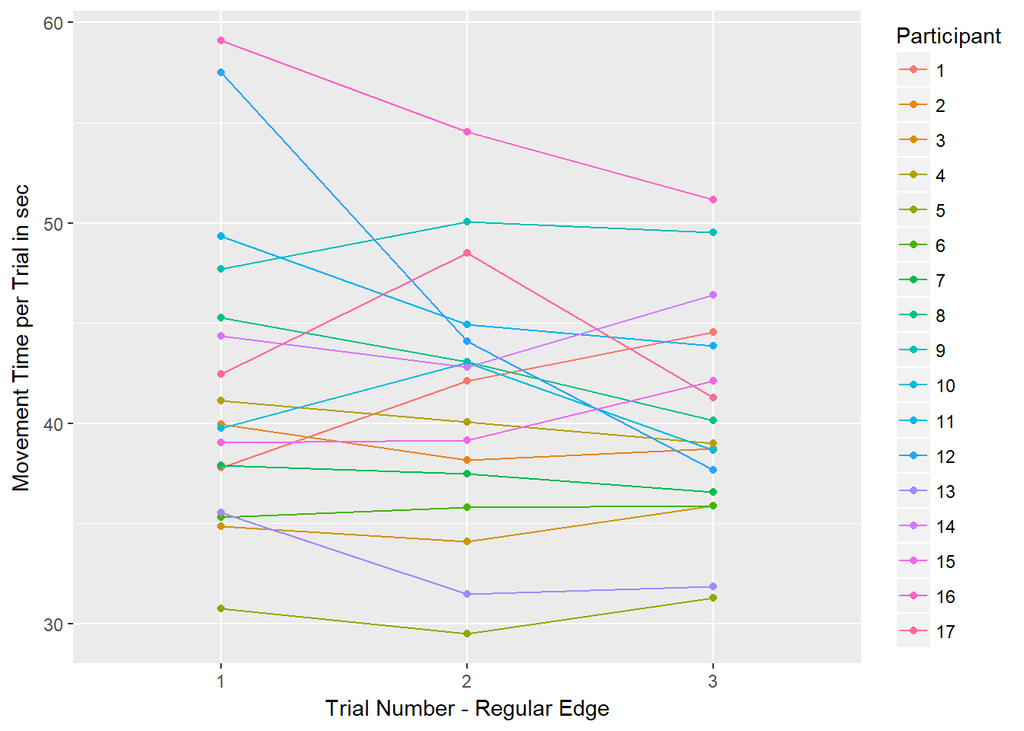

```r
ggplot (data = data_per_trial_regular_edge, mapping = aes(x = TrialNumber, y = MovementTime, col = Participant, group = Participant)) +
  geom_point() +
  geom_line() +
  labs(x = 'Trial Number - Regular Edge', y = 'Movement Time per Trial in sec')
```

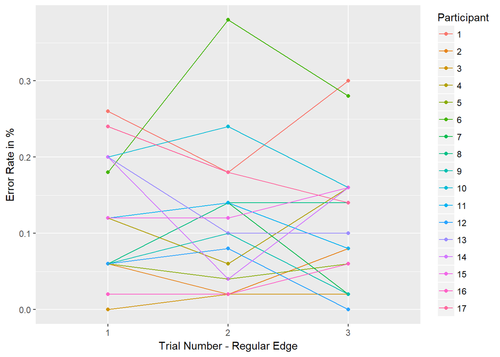

```r
# Lineplot of the calculated error rate average
ggplot (data = data_per_trial_regular_edge, mapping = aes(x = TrialNumber, y = ErrorRate, col = Participant, group = Participant)) +
  geom_point() +
  geom_line() +
  labs(x = 'Trial Number - Regular Edge', y = 'Error Rate in %')
```

### Average movement time per participant for virtual edge condition (lineplot)

Lineplot which displays the average time that each participant needed to complete a task.

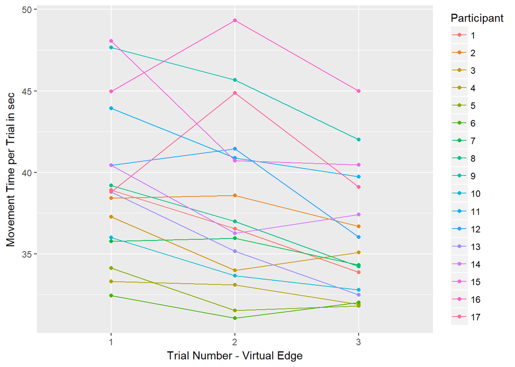

```r
ggplot (data = data_per_trial_virtual_edge, mapping = aes(x = TrialNumber, y = MovementTime, col = Participant, group = Participant)) +
  geom_point() +
  geom_line() +
  labs(x = 'Trial Number - Virtual Edge', y = 'Movement Time per Trial in sec')
```

### Average error rate per participant for virtual edge condition (lineplot)

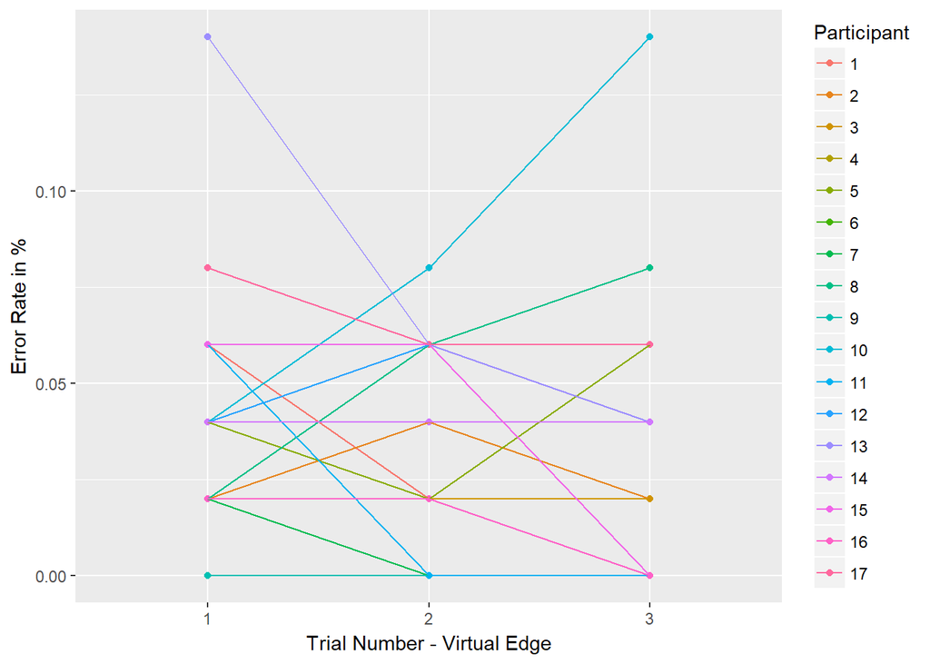

```r
# Lineplot of the calculated error rate average
ggplot (data = data_per_trial_virtual_edge, mapping = aes(x = TrialNumber, y = ErrorRate, col = Participant, group = Participant)) +
  geom_point() +
  geom_line() +
  labs(x = 'Trial Number - Virtual Edge', y = 'Error Rate in %')
```

### Relationship between MovementTime and Regular Edge Trials.

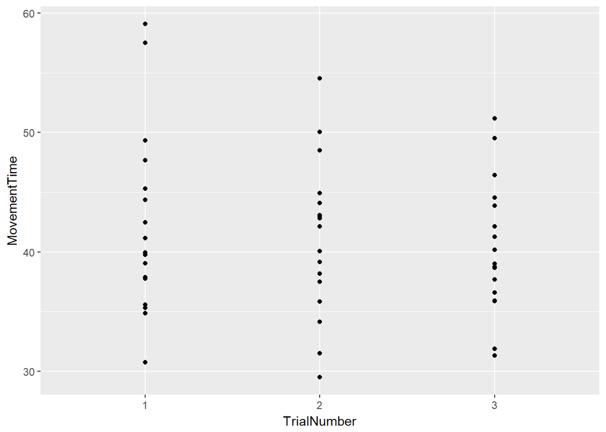

```r
data_per_trial_regular_edge %>%
  ggplot(., aes(x = TrialNumber, y = MovementTime)) +
  geom_point() +
  geom_smooth(method = "lm", size = 1.5, color = "red")
```

### Relationship between MovementTime and Virtual Edge Trials.

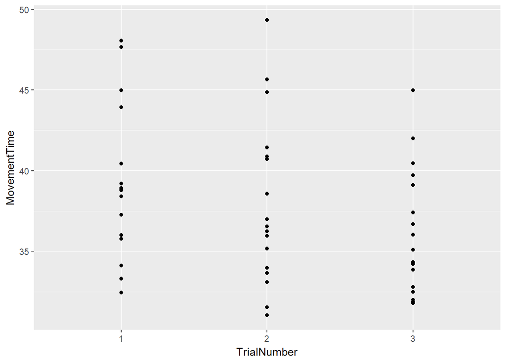

```r
data_per_trial_virtual_edge %>%
  ggplot(., aes(x = TrialNumber, y = MovementTime)) +
  geom_point() +
  geom_smooth(method = "lm", size = 1.5, color = "red")
```

### Movemement time: mean and unadjusted confidence interval for each trial and each condition.

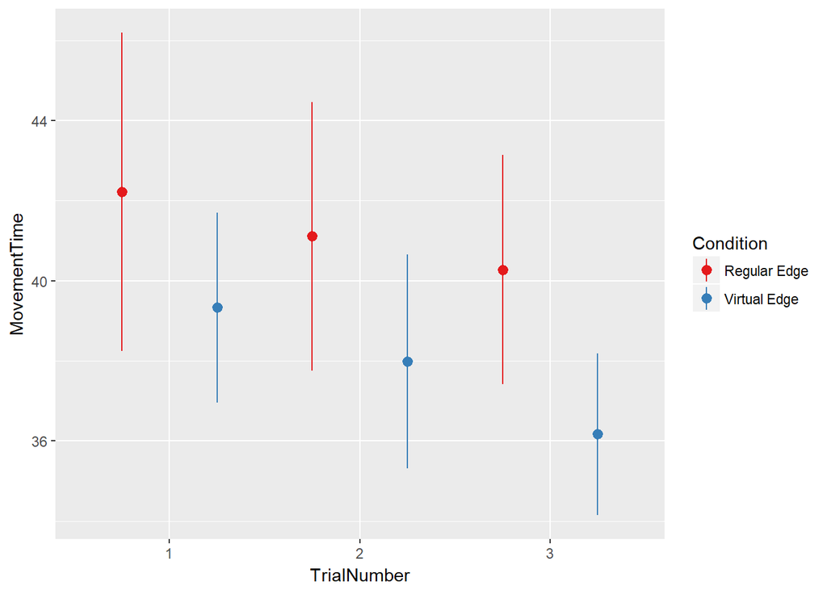

```r
ggplot(data_per_trial, aes(TrialNumber, MovementTime, color=Condition)) +
  stat_summary(fun.data = "mean_cl_normal", position = position_dodge(width = 1)) + scale_color_brewer(palette = "Set1")
```

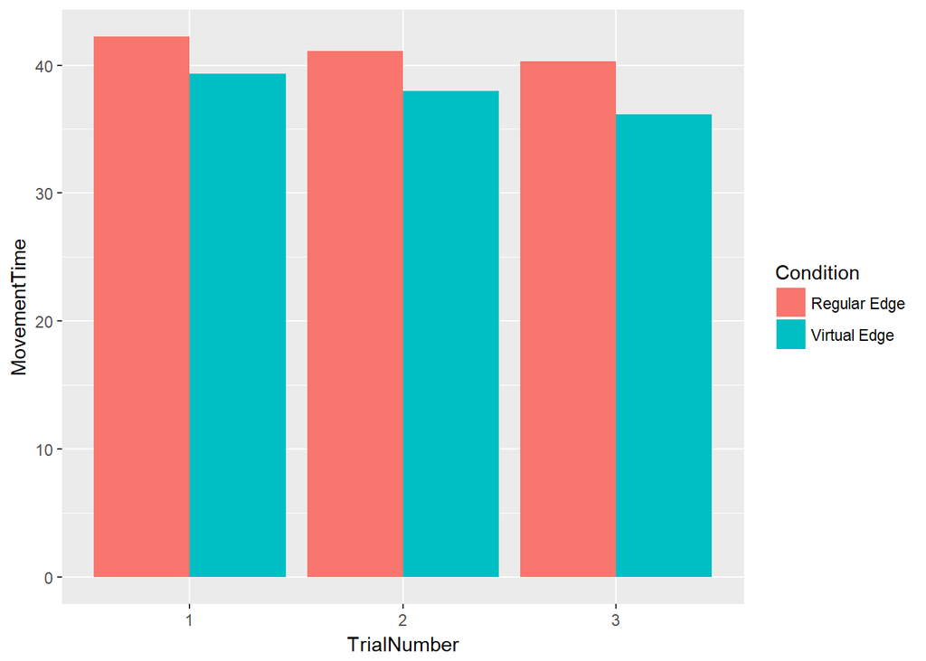

```r
ggplot(data_per_trial, aes(TrialNumber, MovementTime, fill=Condition)) +
  stat_summary(fun.data = "mean_cl_normal", geom = "bar", position = "dodge") +  scale_color_brewer(palette = "Set1")
```

Movement time: we see that the mean for virtual edges is slightly smaller and the confidence intervals overlap. We also see the difference between the two conditions seem to increase with the number of trials.

### Relationship between Error Rate and Regular Edge Trials.

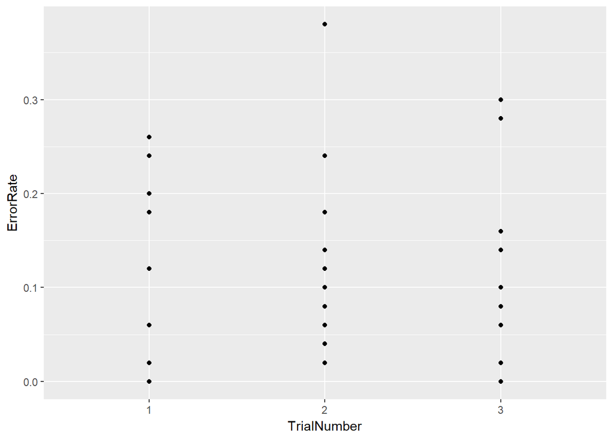

```r
data_per_trial_regular_edge %>%
  ggplot(., aes(x = TrialNumber, y = ErrorRate)) +
  geom_point() +
  geom_smooth(method = "lm", size = 1.5, color = "red")
```

### Relationship between Error Rate and Virtual Edge Trials.

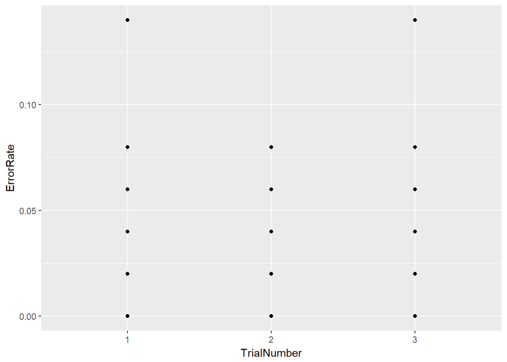

```r
data_per_trial_virtual_edge %>%
  ggplot(., aes(x = TrialNumber, y = ErrorRate)) +
  geom_point() +
  geom_smooth(method = "lm", size = 1.5, color = "red")
```

### Error Rate: mean and unadjusted confidence interval for each trial and each condition.

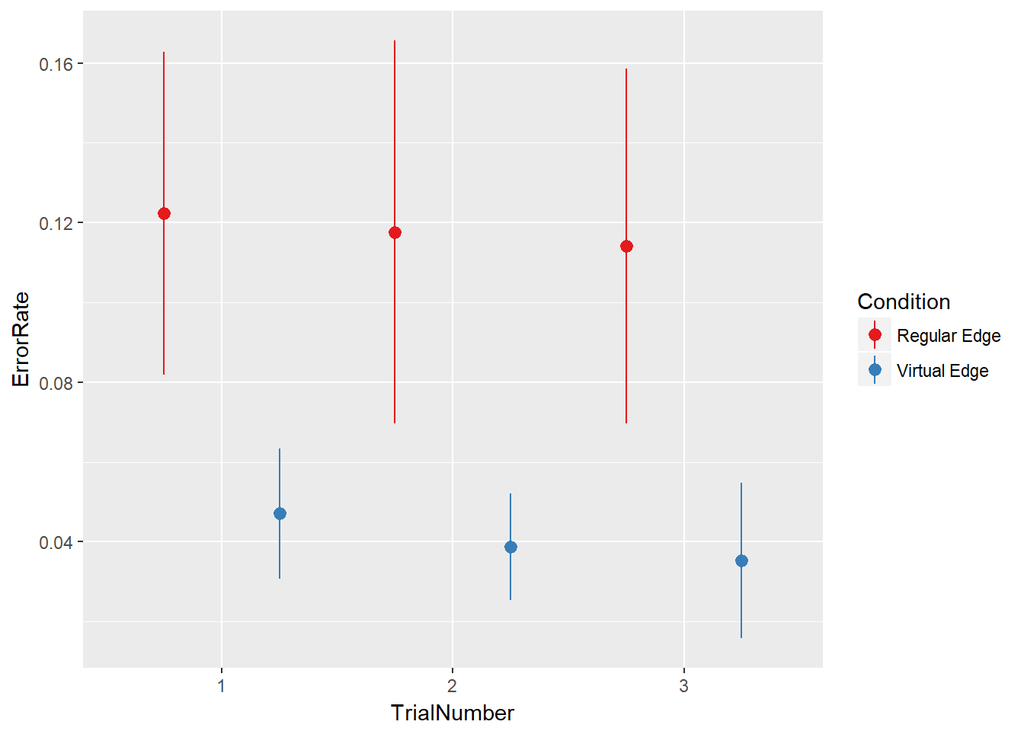

```r
ggplot(data_per_trial, aes(TrialNumber, ErrorRate, color=Condition)) +
  stat_summary(fun.data = "mean_cl_normal", position = position_dodge(width = 1)) + scale_color_brewer(palette = "Set1")
```

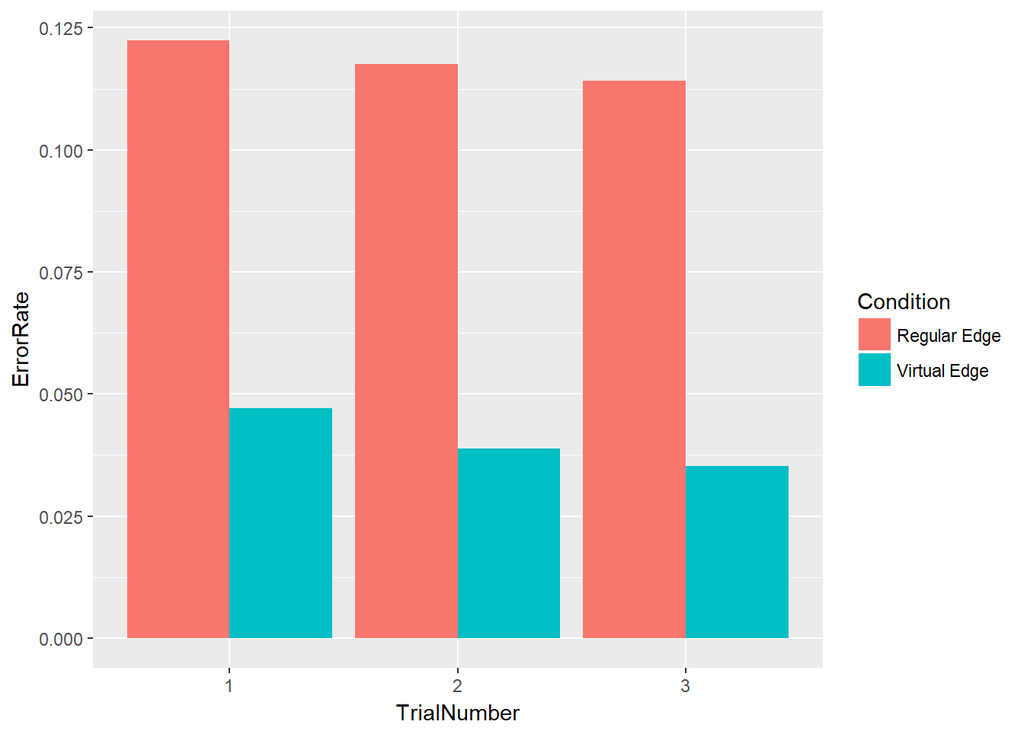

```r
ggplot(data_per_trial, aes(TrialNumber, ErrorRate, fill=Condition)) +
  stat_summary(fun.data = "mean_cl_normal", geom = "bar", position = "dodge") +  scale_color_brewer(palette = "Set1")
```

Error Rate: We see that the mean for virtual edges is smaller and the confidence intervals do not lap.

## Assumbption on the data (original data)

### Normality assumption for Movement Time

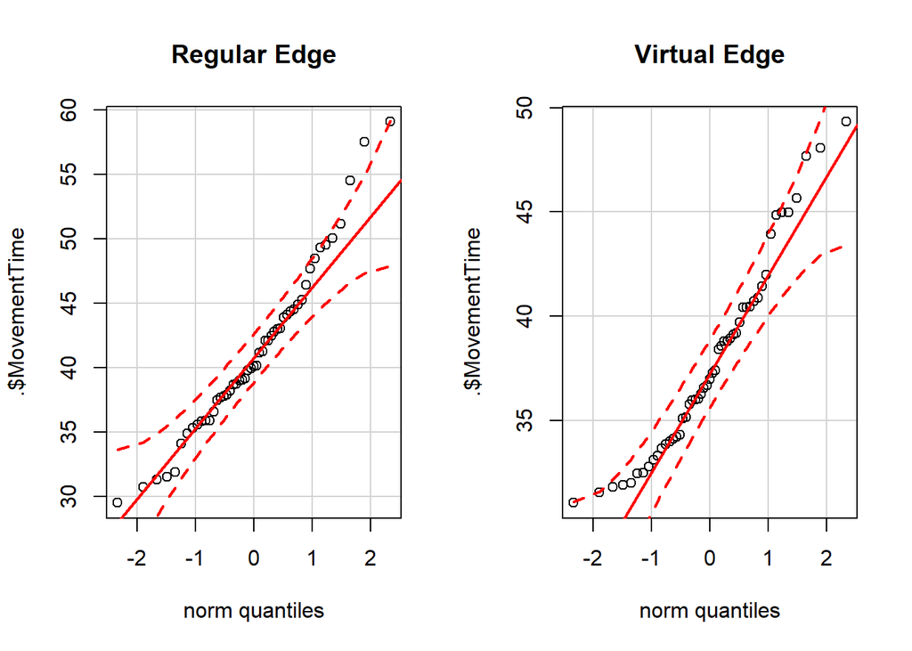

```
## # A tibble: 2 x 4
## # Groups:   Condition [2]
##   Condition    statistic p.value method
##   <fct>            <dbl>   <dbl> <fct>
## 1 Regular Edge    0.0924   0.340 Lilliefors (Kolmogorov-Smirnov) normalit~
## 2 Virtual Edge    0.0871   0.434 Lilliefors (Kolmogorov-Smirnov) normalit~
```

```r
par(mfrow = c(1,2)) #plot two plots next to each other
data_per_trial %>%
  group_by(Condition) %>%
  do({
    qqPlot(.$MovementTime)
    title(main=.$Condition[[1]])
    tidy(lillie.test(.$MovementTime))
  })
```

```r
par(mfrow = c(1,1)) # sets back the default
```

### Normality assumption for Error Rate

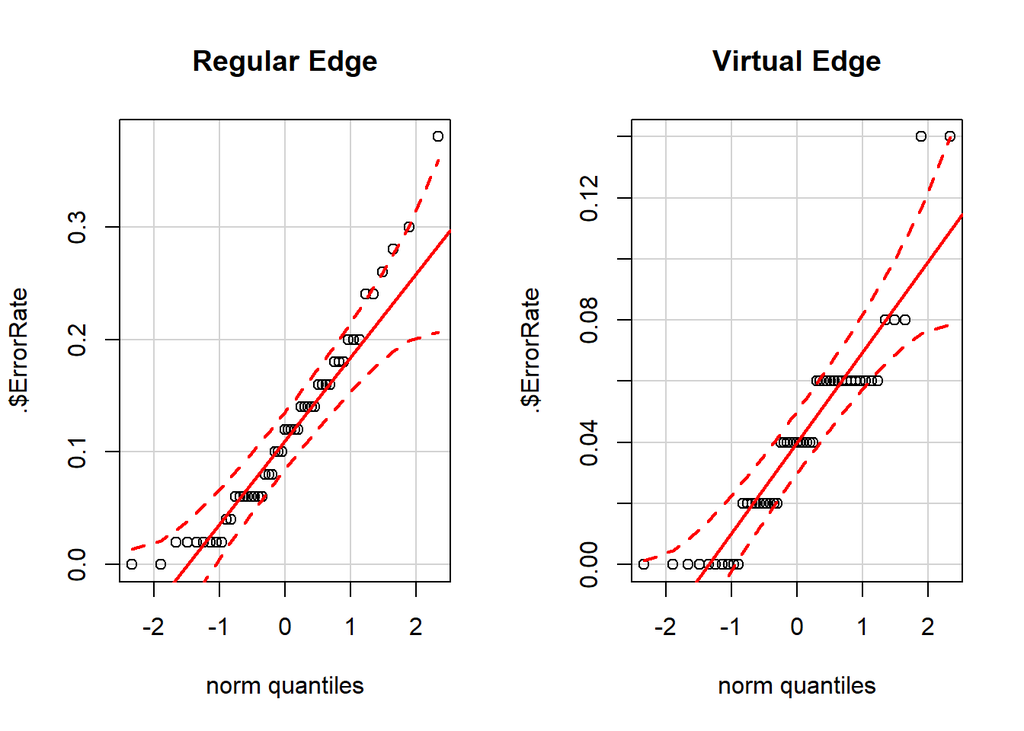

```
## # A tibble: 2 x 4
## # Groups:   Condition [2]
##   Condition    statistic  p.value method
##   <fct>            <dbl>    <dbl> <fct>
## 1 Regular Edge     0.126 0.0420   Lilliefors (Kolmogorov-Smirnov) normali~
## 2 Virtual Edge     0.171 0.000716 Lilliefors (Kolmogorov-Smirnov) normali~
```

```r
par(mfrow = c(1,2)) #plot two plots next to each other
data_per_trial %>%
  group_by(Condition) %>%
  do({
    qqPlot(.$ErrorRate)
    title(main=.$Condition[[1]])
    tidy(lillie.test(.$ErrorRate))
  })
```

```r
par(mfrow = c(1,1)) # sets back the default
```

## Log Transformation for Error Rate

### Normality assumption for log of Error Rate

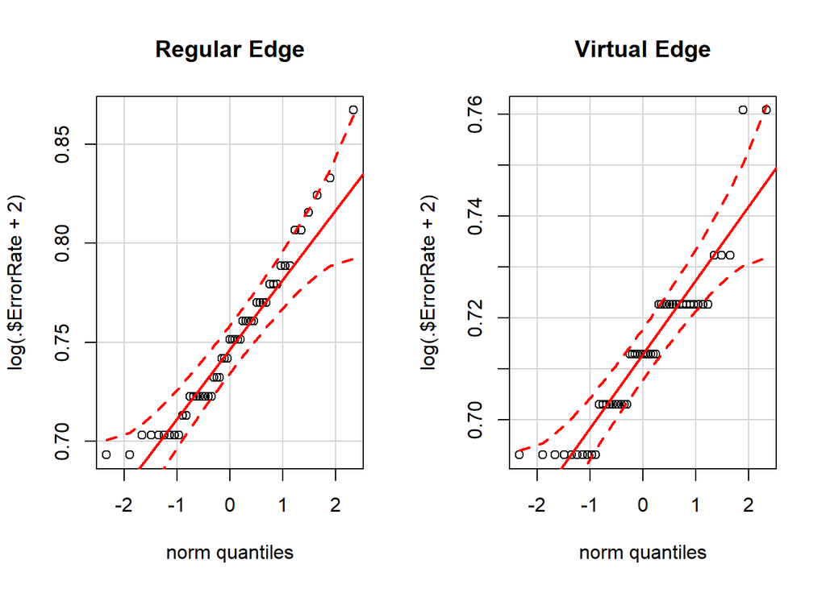

```
## # A tibble: 2 x 4
## # Groups:   Condition [2]
##   Condition    statistic  p.value method
##   <fct>            <dbl>    <dbl> <fct>
## 1 Regular Edge     0.126 0.0418   Lilliefors (Kolmogorov-Smirnov) normali~
## 2 Virtual Edge     0.168 0.000980 Lilliefors (Kolmogorov-Smirnov) normali~
```

```r
par(mfrow = c(1,2)) #plot two plots next to each other
data_per_trial %>%
  group_by(Condition) %>%
  do({
    qqPlot(log(.$ErrorRate + 2))
    title(main=.$Condition[[1]])
    tidy(lillie.test(log(.$ErrorRate + 2)))
  })
```

```r
par(mfrow = c(1,1)) # sets back the default
```

## Linear model for MovementTime

We fit a linear model between MovementTime, Condition and their interaction.

```r
fit_movementTime <- lm(MovementTime ~ Condition*TrialNumber, data_per_trial)
```

### Analysis of variance (ANOVA)

Comparing to the null model: (there’s no relationship between movementTime and condition)

```r
anova_movementTime <- tidy(anova(fit_movementTime))
anova_movementTime
```

```
##                    term df       sumsq     meansq statistic     p.value
## 1             Condition  1  290.572338 290.572338 8.8678946 0.003674251
## 2           TrialNumber  2  110.711649  55.355825 1.6893887 0.190074569
## 3 Condition:TrialNumber  2    7.049189   3.524594 0.1075661 0.898125245
## 4             Residuals 96 3145.610727  32.766778        NA          NA
```

### Update model to exclude interaction

```r
fit_movementTime <- update(fit_movementTime, .~. - Condition:TrialNumber)
```

### AIC model assessment

Goal: find the model with lowest AIC

```r
step_backward_result <-
  MASS::stepAIC(fit_movementTime,
    direction = "backward",
    trace = TRUE
    )
```

```
## Start:  AIC=357.96
## MovementTime ~ Condition + TrialNumber
##
##               Df Sum of Sq    RSS    AIC
## - TrialNumber  2    110.71 3263.4 357.49
## <none>                     3152.7 357.96
## - Condition    1    290.57 3443.2 364.96
##
## Step:  AIC=357.49
## MovementTime ~ Condition
##
##             Df Sum of Sq    RSS    AIC
## <none>                   3263.4 357.49
## - Condition  1    290.57 3553.9 364.19
```

**Interpretation:** The AIC-score shows the best (lowest) value when the trial number is removed.

### Update model to exclude trial number

```r
fit_movementTime <- update(fit_movementTime, .~. - TrialNumber)
```

Then, we plot the residuals to check if they seem to be normally distributed

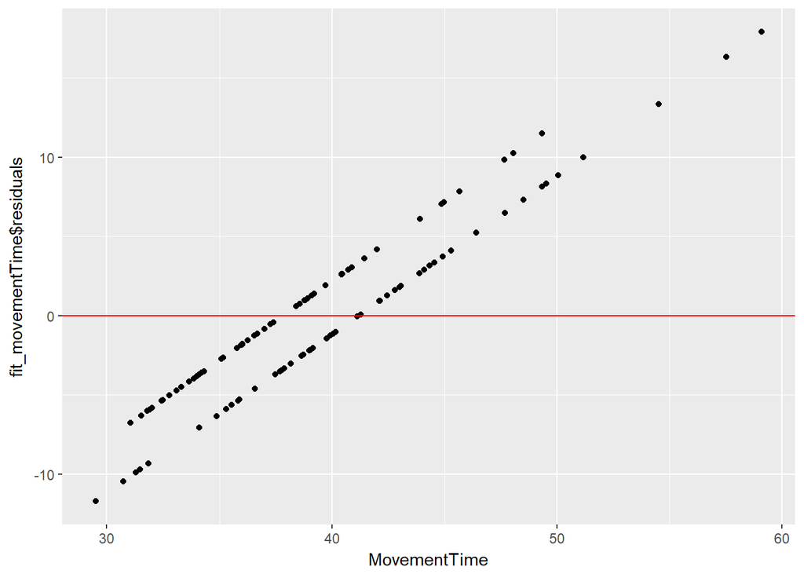

```r
p_M_C_resid <- data_per_trial %>%
  ggplot(., aes(x = MovementTime, y = fit_movementTime$residuals)) +
  geom_point() +
  geom_hline(yintercept = 0, col = "red")
p_M_C_resid
```

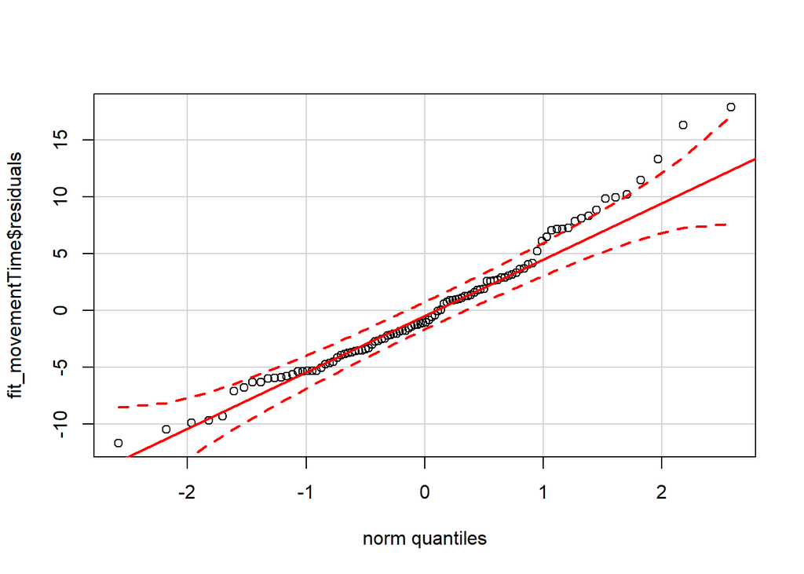

```r
car::qqPlot(fit_movementTime$residuals)
```

From QQ-plot, we see that the residuals are normally distributed.

We check if the residuals have similar variance

```r
car::ncvTest(fit_movementTime)
```

```
## Non-constant Variance Score Test
## Variance formula: ~ fitted.values
## Chisquare = 5.350817    Df = 1     p = 0.02071257
```

### Log-transformation of movement time

```r
fit_movementTime <- lm(log(MovementTime) ~ Condition, data_per_trial)
```

Then, we plot the residuals to check if they seem to be normally distributed

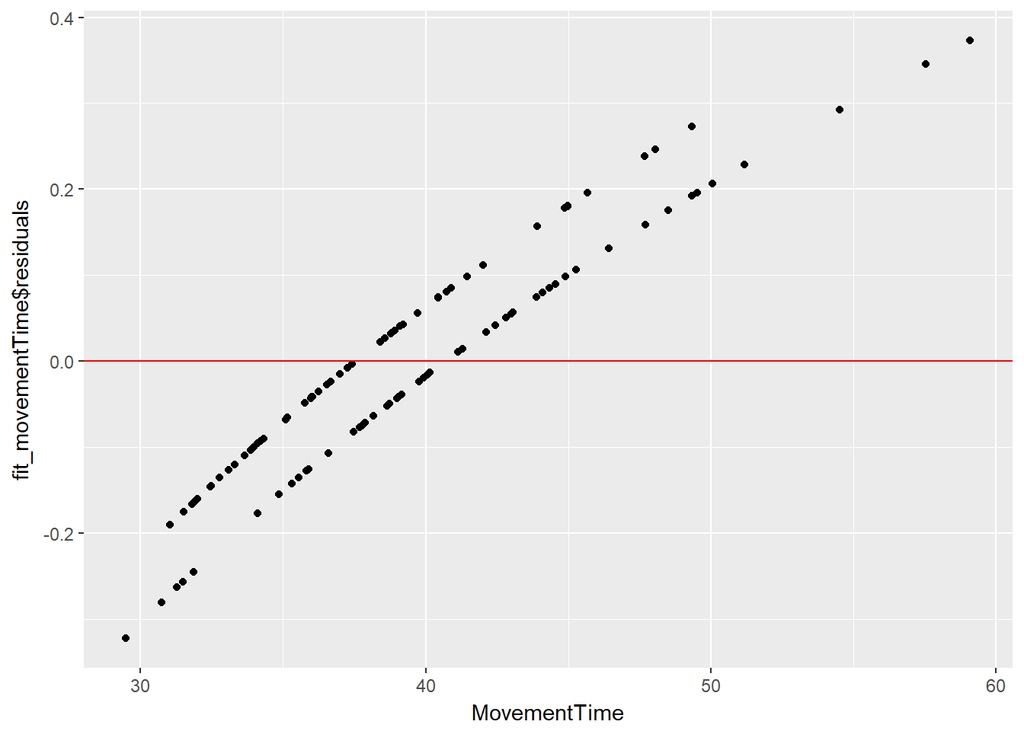

```r
p_M_C_resid <- data_per_trial %>%
  ggplot(., aes(x = MovementTime, y = fit_movementTime$residuals)) +
  geom_point() +
  geom_hline(yintercept = 0, col = "red")
p_M_C_resid
```

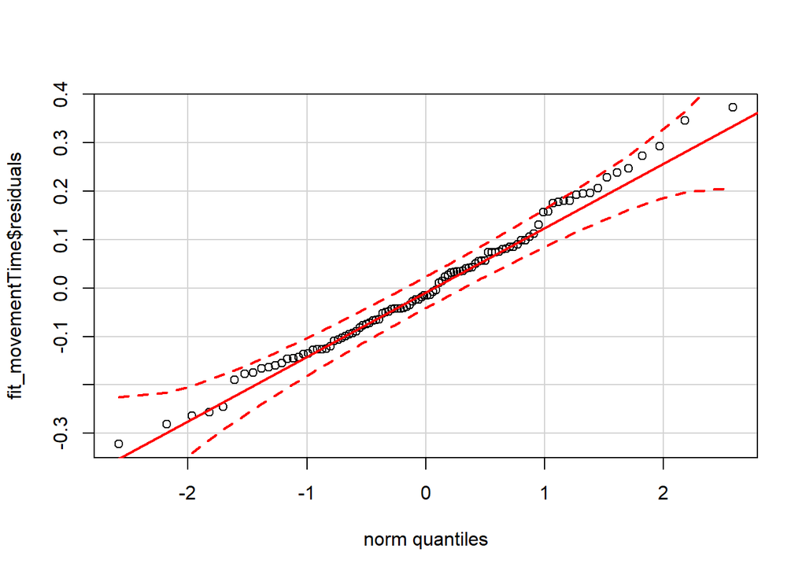

```r
car::qqPlot(fit_movementTime$residuals)
```

From QQ-plot, we see that the residuals are normally distributed.

We check if the residuals have similar variance

```r
car::ncvTest(fit_movementTime)
```

```
## Non-constant Variance Score Test
## Variance formula: ~ fitted.values
## Chisquare = 3.192899    Df = 1     p = 0.07395875
```

### Pairwise comparison for movement time

```r
pairwise_movementTime <- glht(fit_movementTime, linfct = mcp(Condition = "Tukey"))
ci_pairwise_movementTime <- tidy(confint(pairwise_movementTime))
ci_pairwise_movementTime
```

```
##                           lhs rhs    estimate   conf.low   conf.high
## 1 Virtual Edge - Regular Edge   0 -0.08068544 -0.1355594 -0.02581149
```

### Reverse the log transformation

```r
ci_pairwise_antilog_ratio <-
  tidy(confint(pairwise_movementTime)) %>%
  mutate(
    estimate = exp(estimate),
    conf.low = exp(conf.low),
    conf.high = exp(conf.high)
  ) %>%
  separate(lhs, c("competitor", "Condition"), sep = " - ") %>%
  select(-rhs)
ci_pairwise_antilog_ratio
```

```
##     competitor    Condition  estimate  conf.low conf.high
## 1 Virtual Edge Regular Edge 0.9224838 0.8732273 0.9745188
```

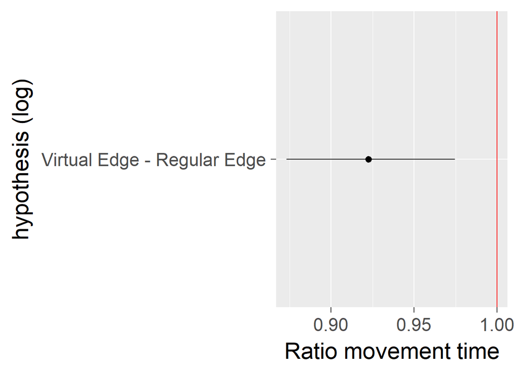

```r
p_pairwise_antilog_ratio <-
  ci_pairwise_antilog_ratio %>%
  mutate(hypothesis = str_c(competitor, " - ", Condition)) %>%
  ggplot(aes(x = hypothesis, y = estimate, ymin = conf.low, ymax = conf.high)) +
  geom_hline(yintercept = 1, color = "red") +
  geom_pointrange() +
  coord_flip() +
  xlab("hypothesis (log)") +
  ylab("Ratio movement time")  +
  theme_grey(base_size = 22)
p_pairwise_antilog_ratio
```

```r
summary_geom_mean <-
  data_per_trial %>%
  group_by(Condition) %>%
  do({mean_cl_geom(.$MovementTime)}) %>%
  rename(
    mean_geom = y,
    conf_low = ymin,
    conf_high = ymax) %>%
  ungroup()

ci_pairwise_antilog_s <-
  summary_geom_mean %>%
  select(Condition, mean_geom) %>%
  mutate(Condition = as.character(Condition)) %>%
  right_join(ci_pairwise_antilog_ratio, by = c("Condition")) %>%
  mutate(
    estimate_s = (mean_geom * estimate) - mean_geom,
    conf_low_s = (mean_geom * conf.low) - mean_geom,
    conf_high_s = (mean_geom * conf.high) - mean_geom
  ) %>%
  select(Condition, competitor, estimate_s, conf_low_s, conf_high_s)
ci_pairwise_antilog_s
```

```
## # A tibble: 1 x 5
##   Condition    competitor   estimate_s conf_low_s conf_high_s
##   <chr>        <chr>             <dbl>      <dbl>       <dbl>
## 1 Regular Edge Virtual Edge      -3.16      -5.16       -1.04
```

[figure not shown]

```r
p_pairwise_antilog_s <-
  ci_pairwise_antilog_s %>%
  mutate(hypothesis = str_c(competitor, " - ", Condition)) %>%
  ggplot(aes(x = hypothesis, y = estimate_s, ymin = conf_low_s, ymax = conf_high_s)) +
  geom_pointrange() +
  geom_hline(yintercept = 0, color = "red") +
  ylab("milliseconds") +
  xlab("") +
  coord_flip() +
  theme_grey(base_size = 22)
p_pairwise_antilog_s
```

## Linear model for Error Rate

We fit a linear model between Error Rate, Condition and their interaction.

```r
fit_errorRate <- lm(log(ErrorRate +2) ~ Condition*TrialNumber, data_per_trial)
```

### Analysis of variance (ANOVA)

```r
anova_errorRate <- tidy(anova(fit_errorRate))
anova_errorRate
```

```
##                    term df        sumsq       meansq    statistic
## 1             Condition  1 3.434316e-02 3.434316e-02 36.940046867
## 2           TrialNumber  2 4.242495e-04 2.121248e-04  0.228164736
## 3 Condition:TrialNumber  2 1.601826e-05 8.009132e-06  0.008614748
## 4             Residuals 96 8.925121e-02 9.297001e-04           NA
##        p.value
## 1 2.457202e-08
## 2 7.964235e-01
## 3 9.914230e-01
## 4           NA
```

### Update model to exclude interaction

```r
fit_errorRate <- update(fit_errorRate, .~. - Condition:TrialNumber)
```

### AIC model assessment

Goal: find the model with lowest AIC

```r
step_backward_result <-
  MASS::stepAIC(fit_errorRate,
    direction = "backward",
    trace = TRUE
    )
```

```
## Start:  AIC=-710.19
## log(ErrorRate + 2) ~ Condition + TrialNumber
##
##               Df Sum of Sq      RSS     AIC
## - TrialNumber  2  0.000424 0.089691 -713.71
## <none>                     0.089267 -710.19
## - Condition    1  0.034343 0.123610 -678.99
##
## Step:  AIC=-713.71
## log(ErrorRate + 2) ~ Condition
##
##             Df Sum of Sq      RSS     AIC
## <none>                   0.089691 -713.71
## - Condition  1  0.034343 0.124035 -682.64
```

**Interpretation:** The AIC-score shows the best (lowest) value when the trial number is removed.

### Update model to exclude trial number

```r
fit_errorRate <- update(fit_errorRate, .~. - TrialNumber)
```

Then, we plot the residuals to check if they seem to be normally distributed

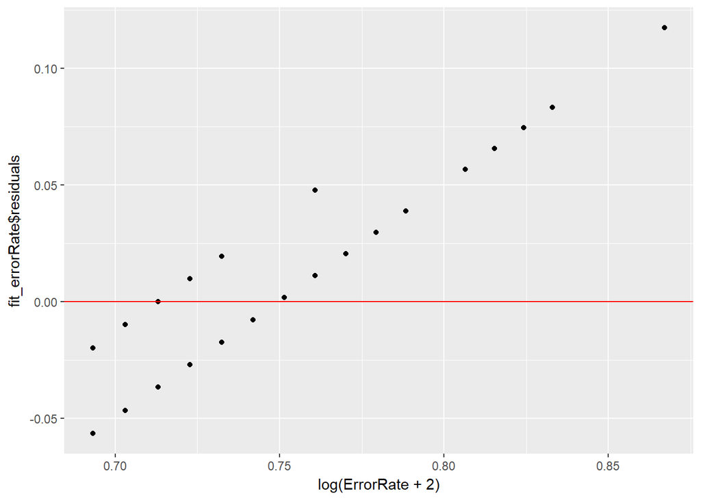

```r
p_E_C_resid <- data_per_trial %>%
  ggplot(., aes(x = log(ErrorRate + 2), y = fit_errorRate$residuals)) +
  geom_point() +
  geom_hline(yintercept = 0, col = "red")
p_E_C_resid
```

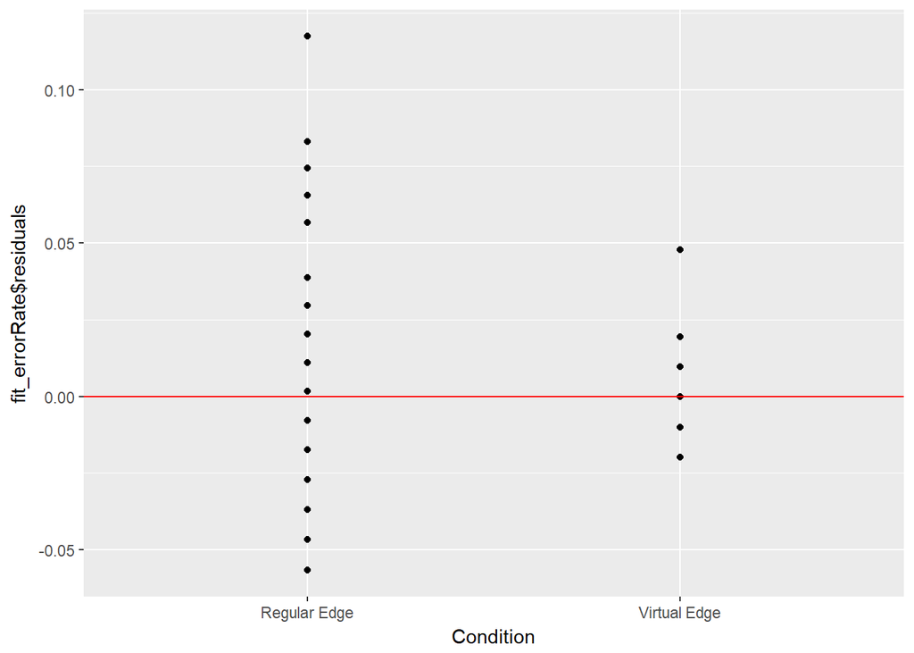

```r
p_E_C_resid <- data_per_trial %>%
  ggplot(., aes(x = Condition, y = fit_errorRate$residuals)) +
  geom_point() +
  geom_hline(yintercept = 0, col = "red")
p_E_C_resid
```

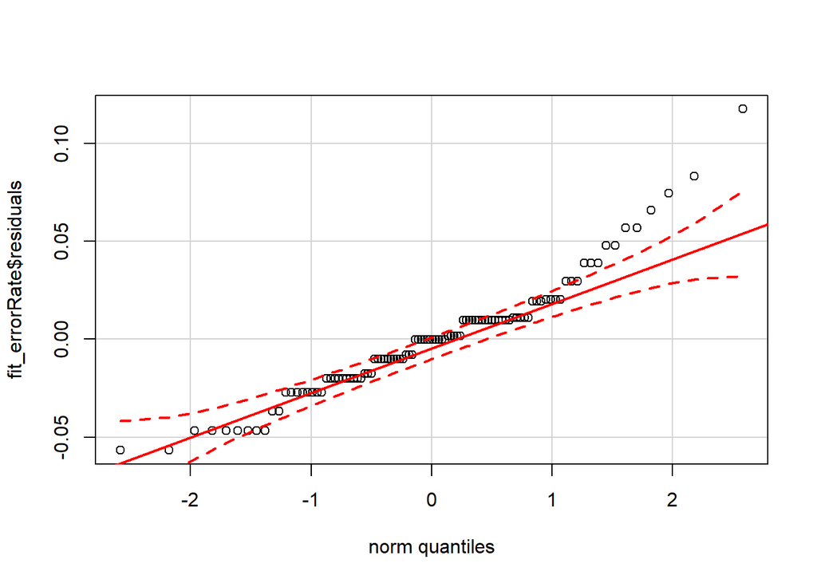

```r
car::qqPlot(fit_errorRate$residuals)
```

From QQ-plot, we see that the residuals do not follow a normal distribution.

We check if the residuals have similar variance

```r
car::ncvTest(fit_errorRate)
```

```
## Non-constant Variance Score Test
## Variance formula: ~ fitted.values
## Chisquare = 27.3062    Df = 1     p = 1.736539e-07
```

Since the residuals are neither normally distributed nor have similar variance, we perform a Aligned Rank Transformation (ART)

```r
art_errorRate <- art(ErrorRate ~ Condition, data_per_trial)

data_per_trial$ErrorRate_art_Condition <- art_errorRate$aligned.ranks$Condition

m_art_Condition <- lm(ErrorRate_art_Condition ~ Condition, data_per_trial)
summary(m_art_Condition)
```

```
##
## Call:
## lm(formula = ErrorRate_art_Condition ~ Condition, data = data_per_trial)
##
## Residuals:
##     Min      1Q  Median      3Q     Max
## -60.176 -15.324   1.824  17.676  46.676
##
## Coefficients:
##                       Estimate Std. Error t value Pr(>|t|)
## (Intercept)             66.676      3.518  18.953  < 2e-16 ***
## ConditionVirtual Edge  -30.353      4.975  -6.101 2.01e-08 ***
## ---
## Signif. codes:  0 '***' 0.001 '**' 0.01 '*' 0.05 '.' 0.1 ' ' 1
##
## Residual standard error: 25.12 on 100 degrees of freedom
## Multiple R-squared:  0.2712, Adjusted R-squared:  0.264
## F-statistic: 37.22 on 1 and 100 DF,  p-value: 2.007e-08
```

### Pairwise comparison for movement time

```r
pairwise_movementTime <- glht(fit_movementTime, linfct = mcp(Condition = "Tukey"))
ci_pairwise_movementTime <- tidy(confint(pairwise_movementTime))
scale_factor <- sigmaHat(fit_movementTime)
ci_pairwise_movementTime <-
  ci_pairwise_movementTime %>%
  mutate(
    estimate  = estimate / scale_factor,
    conf.low  = conf.low / scale_factor,
    conf.high = conf.high / scale_factor
  )

ci_pairwise_movementTime
```

```
##                           lhs rhs   estimate   conf.low  conf.high
## 1 Virtual Edge - Regular Edge   0 -0.5776893 -0.9705742 -0.1848044
```

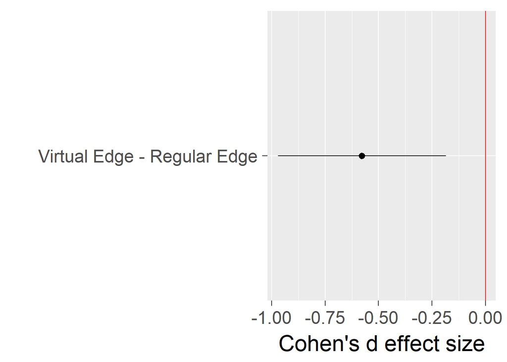

```r
p_pairwise_movementTime <-
  ci_pairwise_movementTime %>%
  ggplot(aes(x = lhs, y = estimate, ymin = conf.low, ymax = conf.high)) +
  geom_pointrange() +
  geom_hline(yintercept = 0, color = "red") +
  xlab("") +
  ylab("Cohen's d effect size") +
  coord_flip()  +
  theme_grey(base_size = 22)
p_pairwise_movementTime
```

### Pairwise comparison for error rate

```r
pairwise_art_Condition <- glht(m_art_Condition, linfct = mcp(Condition = "Tukey"))
ci_pairwise_art_Condition <- tidy(confint(pairwise_art_Condition))
scale_factor <- sigmaHat(m_art_Condition)
ci_pairwise_art_Condition <-
  ci_pairwise_art_Condition %>%
  mutate(
    estimate  = estimate / scale_factor,
    conf.low  = conf.low / scale_factor,
    conf.high = conf.high / scale_factor
  )
ci_pairwise_art_Condition
```

```
##                           lhs rhs  estimate  conf.low  conf.high
## 1 Virtual Edge - Regular Edge   0 -1.208137 -1.601022 -0.8152521
```

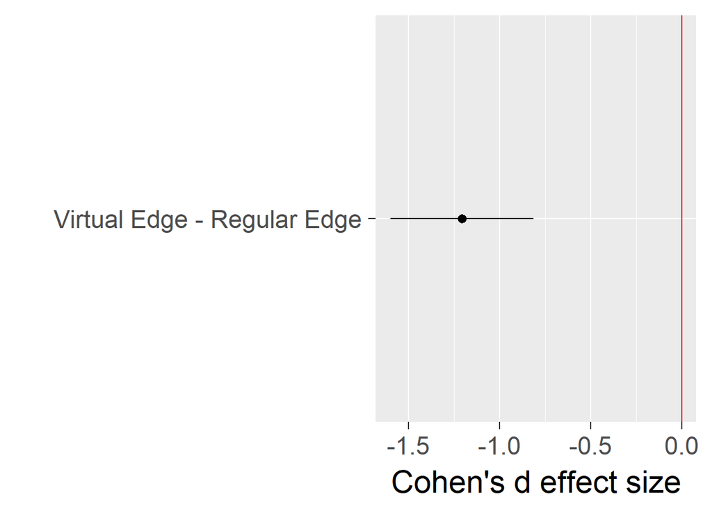

```r
p_pairwise_art_Condition <-
  ci_pairwise_art_Condition %>%
  ggplot(aes(x = lhs, y = estimate, ymin = conf.low, ymax = conf.high)) +
  geom_pointrange() +
  geom_hline(yintercept = 0, color = "red") +
  xlab("") +
  ylab("Cohen's d effect size") +
  coord_flip()  +
  theme_grey(base_size = 22)
p_pairwise_art_Condition
```